# Prediction Assignment - Practical Machine Learning

David Álvarez Pons

## Introduction

In this project we will try to predict how well barbells are performed based on the data obtained from several accelerometers disposed around the arms, belt and dumbell. First, we will perform some **exploratory analysis** to understand better what data we are working with. After that, we will show how to **build a model** using **cross validation**, explain the main **decisions** taken and computing the final **sample error**. We will use the `caret` package as explained in the lectures.

## Exploratory Analysis

### Downloading Data

The data for this project come from this source: http://groupware.les.inf.puc-rio.br/har.

```r
# Urls and Names
fileUrls <- c(
    "https://d396qusza40orc.cloudfront.net/predmachlearn/pml-training.csv",
    "https://d396qusza40orc.cloudfront.net/predmachlearn/pml-testing.csv");
fileNames <- c("./data/training.csv", "./data/testing.csv");
```

### Data Preprocessing

Observing the preprocessed data as can be seen in the Appendix, there are some columns that are considered as factors when they should be numbers, we will fix that. In addition, some columns of the test set are set to `logical` classes and should be set to `numeric`. Finally, a column named `X` was added as a result of reading the data form the CSV, we will remove it from our both data sets, as well as other non-numerical columns. Difference between training set before and after being preprocessed can be seen in the appendix.

### Data Analysis

In this section we will analyse the data to see if there is any obvious relation among features. As we can see in the appendix, we decided to plot the different measures of Accelerometers (`accel`), Gyroscopes (`gyros`) and Magnets (`magnet`) versus the five different classes of performing the barbells. We chose to plot these covariates, although we could have chosen to plot any subset of the other available predictors. In this case, there is **very little correlation** between these covariates with the *classe* of the barbells.

## Prediction Model

In this section we will continue with the problem of variable selection and prediction function selection. We will use cross validation as a tool for taking these decisions. Note that we will **not use PCA** as a possible way to choose the most important variables for our model, due to the **non linearity** of the data.

### Cross validation methodology

In order to choose which kind of cross validation we will use, we will take into account the following assumptions:

1. We consider the different attempts of barbells **time independent**, i.e. the main difference between attempts is due to the purpose of the person wanting to perform the exercice differently from the previous attempts. Hence, we **discard using Time Slices**
2. Considering the size of the `training` set – 19622 – we **discard using Leave One Out Cross Validation** due the computational cost it will envolve.

Having studied the previous considerations, we will apply the **K-fold** method of cross validation to find. The **resampling method is discarded** since the K-fold method ensures testing over all the samples of the training set in an easier way.

For the size of the folds we decide to create chunks that are approximately the 20% of the total size of the training set (19622), that is, 4000.

```r
k_fold <- 5;
```

We will use the variable `k_fold` in the following section.

### Prediction function choice

Using the different folds of the previous section (in the `trainControl` parameter), we will try to find the best possible prediction function. We will consider a single prediction algorithm for each of the different algorithms explained in the lectures, that is: Prediction Trees (`rpart`), Bagging (`treebag`), Boosting (`gbm`). We do not consider any Model Based Prediction algorithm since we think **the data does not follow any specific statistical model**. Additionally, we discard using Random Forests (`rf`) due its long execution time (> 6000 sec).

```r
fc <- trainControl(method = "cv", number=k_fold);
```

### Sample Error

In this table we can see the Accuracy (`acc`) of each of the previous methods as a result of applying K-fold Cross Validation to the training set. We choose the best one in terms of Accuracy for the final prediction on the `testing` data set.

```
##      method    acc                 execTime
## [1,] "rpart"   "0.508969529738194" "20.2"
## [2,] "treebag" "0.987259198322257" "337.247"
## [3,] "gbm"     "0.963866416224721" "384.335"
```

```r
finalModel <- treebagModel;
```

```
## Bagged CART
##
## 19622 samples
##    52 predictor
##     5 classes: 'A', 'B', 'C', 'D', 'E'
##
## No pre-processing
## Resampling: Cross-Validated (5 fold)
##
## Summary of sample sizes: 15698, 15697, 15697, 15699, 15697
##
## Resampling results
##
##   Accuracy   Kappa      Accuracy SD  Kappa SD
##   0.9872592  0.9838819  0.002876848  0.003641118
##
##
```

### Apply Model to Testing

Once we have chosen our best model, it is time to get the predictions in the test data set.

```r
answers <- predict(finalModel, testing);
answers
```

```
##  [1] B A B A A E D B A A B C B A E E A B B B
## Levels: A B C D E
```

We will use the function provided by Coursera to write the answers in the correct format to be submitted.

```r
if (!file.exists("answers")){
    dir.create("answers");
}

pml_write_files = function(x){
  n = length(x)
  for(i in 1:n){
    filename = paste0("answers/problem_id_",i,".txt")
    write.table(x[i],file=filename,quote=FALSE,row.names=FALSE,col.names=FALSE)
  }
}

pml_write_files(answers);
```

## Appendix

```r
# Before preprocessing
str(orgTraining);
```

```
## 'data.frame':    19622 obs. of  160 variables:
##  $ X                       : int  1 2 3 4 5 6 7 8 9 10 ...
##  $ user_name               : Factor w/ 6 levels "adelmo","carlitos",..: 2 2 2 2 2 2 2 2 2 2 ...
##  $ raw_timestamp_part_1    : int  1323084231 1323084231 1323084231 1323084232 1323084232 1323084232 1323084232 1323084232 1323084232 1323084232 ...
##  $ raw_timestamp_part_2    : int  788290 808298 820366 120339 196328 304277 368296 440390 484323 484434 ...
##  $ cvtd_timestamp          : Factor w/ 20 levels "02/12/2011 13:32",..: 9 9 9 9 9 9 9 9 9 9 ...
##  $ new_window              : Factor w/ 2 levels "no","yes": 1 1 1 1 1 1 1 1 1 1 ...
##  $ num_window              : int  11 11 11 12 12 12 12 12 12 12 ...
##  $ roll_belt               : num  1.41 1.41 1.42 1.48 1.48 1.45 1.42 1.42 1.43 1.45 ...
##  $ pitch_belt              : num  8.07 8.07 8.07 8.05 8.07 8.06 8.09 8.13 8.16 8.17 ...
##  $ yaw_belt                : num  -94.4 -94.4 -94.4 -94.4 -94.4 -94.4 -94.4 -94.4 -94.4 -94.4 ...
##  $ total_accel_belt        : int  3 3 3 3 3 3 3 3 3 3 ...
##  $ kurtosis_roll_belt      : Factor w/ 397 levels "","-0.016850",..: 1 1 1 1 1 1 1 1 1 1 ...
##  $ kurtosis_picth_belt     : Factor w/ 317 levels "","-0.021887",..: 1 1 1 1 1 1 1 1 1 1 ...
##  $ kurtosis_yaw_belt       : Factor w/ 2 levels "","#DIV/0!": 1 1 1 1 1 1 1 1 1 1 ...
```

[output cut: 86 more lines]

```r
# After preprocessing;
str(training);
```

```
## 'data.frame':    19622 obs. of  53 variables:
##  $ roll_belt           : num  1.41 1.41 1.42 1.48 1.48 1.45 1.42 1.42 1.43 1.45 ...
##  $ pitch_belt          : num  8.07 8.07 8.07 8.05 8.07 8.06 8.09 8.13 8.16 8.17 ...
##  $ yaw_belt            : num  -94.4 -94.4 -94.4 -94.4 -94.4 -94.4 -94.4 -94.4 -94.4 -94.4 ...
##  $ total_accel_belt    : num  3 3 3 3 3 3 3 3 3 3 ...
##  $ gyros_belt_x        : num  0 0.02 0 0.02 0.02 0.02 0.02 0.02 0.02 0.03 ...
##  $ gyros_belt_y        : num  0 0 0 0 0.02 0 0 0 0 0 ...
##  $ gyros_belt_z        : num  -0.02 -0.02 -0.02 -0.03 -0.02 -0.02 -0.02 -0.02 -0.02 0 ...
##  $ accel_belt_x        : num  -21 -22 -20 -22 -21 -21 -22 -22 -20 -21 ...
##  $ accel_belt_y        : num  4 4 5 3 2 4 3 4 2 4 ...
##  $ accel_belt_z        : num  22 22 23 21 24 21 21 21 24 22 ...
##  $ magnet_belt_x       : num  -3 -7 -2 -6 -6 0 -4 -2 1 -3 ...
##  $ magnet_belt_y       : num  599 608 600 604 600 603 599 603 602 609 ...
##  $ magnet_belt_z       : num  -313 -311 -305 -310 -302 -312 -311 -313 -312 -308 ...
##  $ roll_arm            : num  -128 -128 -128 -128 -128 -128 -128 -128 -128 -128 ...
```

[output cut: 39 more lines]

```r
table(training$classe);
```

```
##
##    A    B    C    D    E
## 5580 3797 3422 3216 3607
```

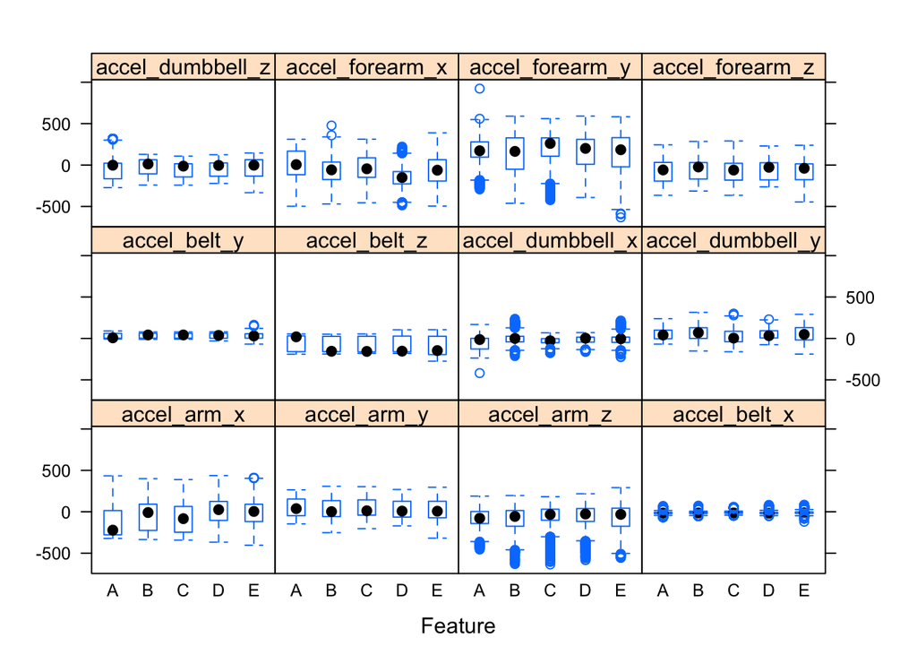

```r
selCols <- grep("^accel_", names(training));
featurePlot(x = training[,selCols],
            y = training$classe,
            plot = "boxplot");
```

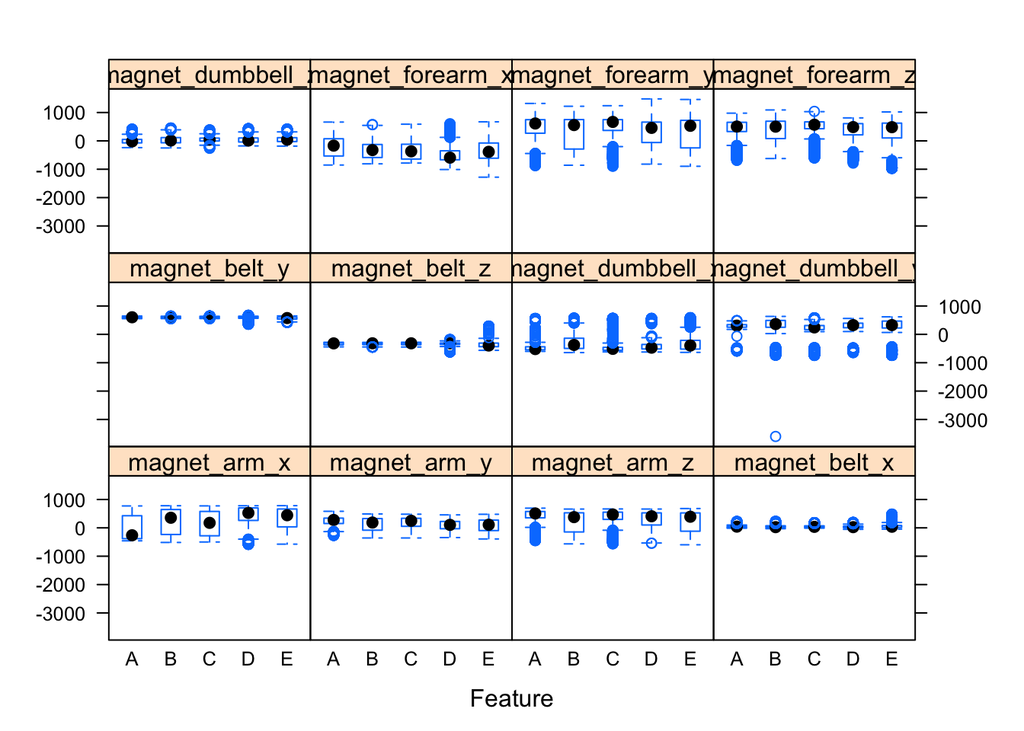

```r
selCols <- grep("^magnet_", names(training));
featurePlot(x = training[,selCols],
            y = training$classe,
            plot = "boxplot");
```

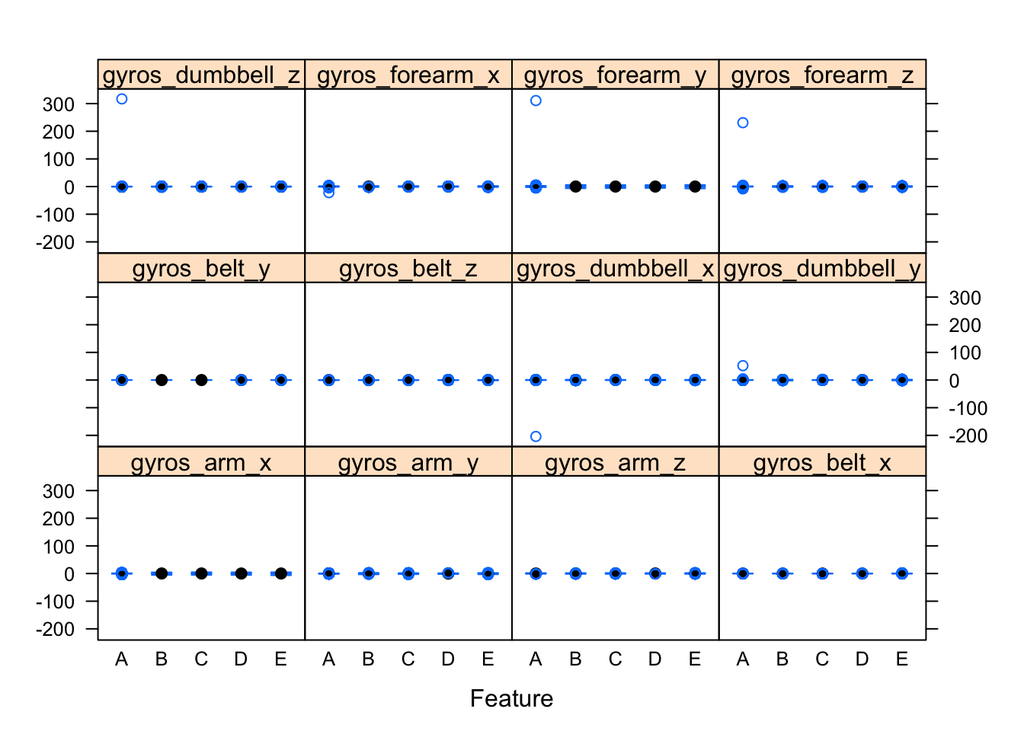

```r
selCols <- grep("^gyros_", names(training));
featurePlot(x = training[,selCols],
            y = training$classe,
            plot = "boxplot");
```